# Analysis and visualization of PISA results

## by Anne

## Investigation Overview

> The analysis of the PISA results shows significant similarities and differences between the participating countries.

## Dataset Overview

> The PISA study is an international study on education. It compared results from lots of countries and also collects different information, e.g. living situation, family situation etc.

## Significant differences in average maths scores between countries

> The average math results per country vary widely. However, there is no clear pattern regarding OECD and Non-OECD countries. While lots of Non-OECD countries don't perform well, the top performers are also Non-OECD countries. Besides that, the variance of the math results is huge in all the countries.

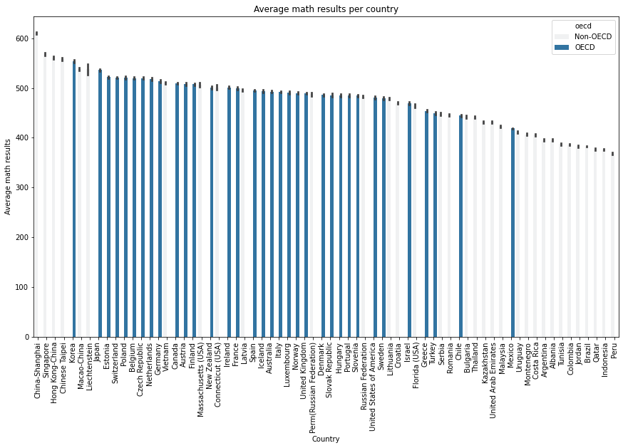

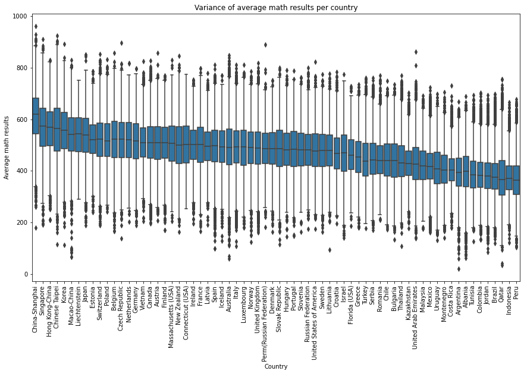

## Same trends in self concept visible in best and worst performing country

> Students from Shanghai achieved the best math results while students from Peru achieved the worst math results. However, there are similar trends visible. If students have a more positive self concept, e.g. students think that they are good at math, they generally perform better.

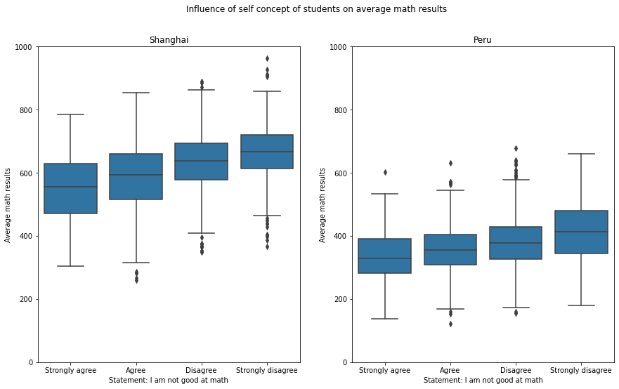

## Education of parents having same effect on male and female students

> On average students achieved the highest math results when their mothers earned an ISCED level 3A degree. Interestingly, if mothers earned an ISCED level 3B or 3C degree, the average math results slightly decrease. The same trends are visible for male and female students.

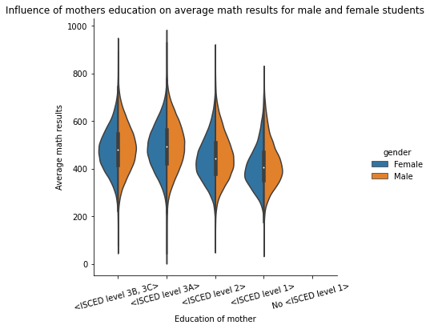